# Cheeseboard learning analysis for ChR2 and eYFP animals

Before running the notebook run trial_stats.R.

Read animal info

Read locations

```
[1] "Reading locations from:  /Users/stella/Desktop/PhD/paulsen lab/Analysis/ChR2vsEYFP/2024-10-02/locations.csv"
```

```
[1] "Reading locations from:  /Users/stella/Desktop/PhD/paulsen lab/Analysis/ChR2vsEYFP/2024-10-03/locations.csv"
```

```
[1] "Reading locations from:  /Users/stella/Desktop/PhD/paulsen lab/Analysis/ChR2vsEYFP/2024-10-04/locations.csv"
```

```
[1] "Reading locations from:  /Users/stella/Desktop/PhD/paulsen lab/Analysis/ChR2vsEYFP/2024-10-05/locations.csv"
[1] "Reading locations from:  /Users/stella/Desktop/PhD/paulsen lab/Analysis/ChR2vsEYFP/2024-10-06/locations.csv"
[1] "Reading locations from:  /Users/stella/Desktop/PhD/paulsen lab/Analysis/ChR2vsEYFP/2024-10-07/locations.csv"
[1] "Reading locations from:  /Users/stella/Desktop/PhD/paulsen lab/Analysis/ChR2vsEYFP/2024-10-08/locations.csv"
[1] "Reading locations from:  /Users/stella/Desktop/PhD/paulsen lab/Analysis/ChR2vsEYFP/2024-12-07/locations.csv"
```

```
[1] "Reading locations from:  /Users/stella/Desktop/PhD/paulsen lab/Analysis/ChR2vsEYFP/2024-12-08/locations.csv"
```

```
[1] "Reading locations from:  /Users/stella/Desktop/PhD/paulsen lab/Analysis/ChR2vsEYFP/2024-12-09/locations.csv"
[1] "Reading locations from:  /Users/stella/Desktop/PhD/paulsen lab/Analysis/ChR2vsEYFP/2024-12-10/locations.csv"
[1] "Reading locations from:  /Users/stella/Desktop/PhD/paulsen lab/Analysis/ChR2vsEYFP/2024-12-11/locations.csv"
[1] "Reading locations from:  /Users/stella/Desktop/PhD/paulsen lab/Analysis/ChR2vsEYFP/2024-12-12/locations.csv"
[1] "Reading locations from:  /Users/stella/Desktop/PhD/paulsen lab/Analysis/ChR2vsEYFP/2024-12-13/locations.csv"
```

```
Warning: incomplete final line found by readTableHeader on '/Users/stella/Desktop/PhD/paulsen lab/Analysis/ChR2vsEYFP/2024-12-13/locations.csv'
```

[output not shown]

Read tracking data

Missing group and learning start date

Traces for example trial

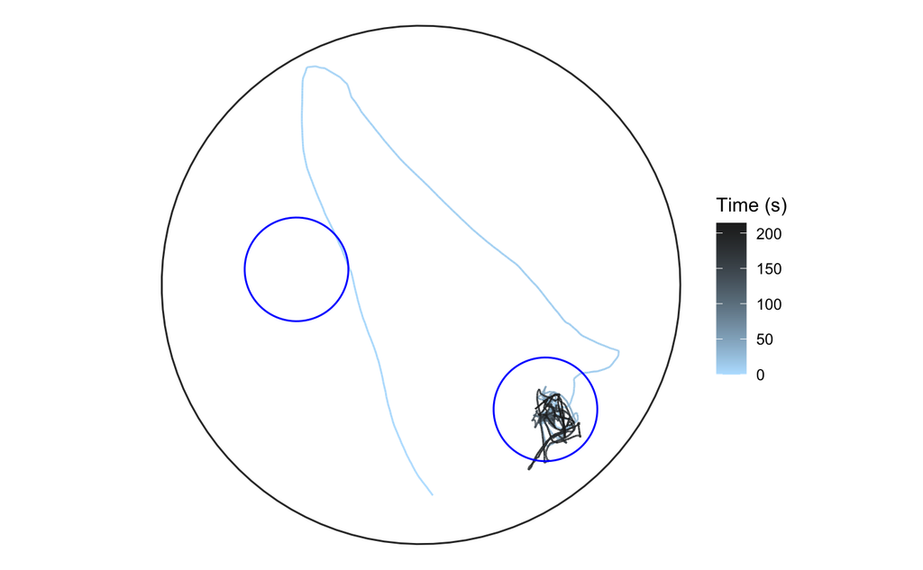

Info about learning trials per animal: number of trials and their duration

| animal | all_trials | learning_trials | mean.dur.s | total.dur.s |
| --- | --- | --- | --- | --- |
| A | 49 | 40 | 170.6232 | 8360.535 |
| AB | 49 | 40 | 172.8098 | 8467.678 |
| AC | 49 | 40 | 176.3728 | 8642.265 |
| C | 49 | 40 | 175.5911 | 8603.965 |
| D | 49 | 40 | 181.6923 | 8902.922 |
| E | 49 | 40 | 145.5733 | 7133.093 |
| EE | 49 | 40 | 166.8391 | 8175.116 |
| EF | 49 | 40 | 180.0498 | 8822.442 |
| F | 49 | 40 | 138.1884 | 6771.231 |
| G | 49 | 40 | 123.3720 | 6045.230 |

Info about number of reward locations

| animal | learning_day | nrewards |
| --- | --- | --- |
| A | 736317 | 2 |
| A | 736318 | 2 |
| A | 736319 | 2 |
| A | 736320 | 2 |
| A | 736321 | 2 |
| A | 736322 | 2 |
| A | 736323 | 2 |
| AB | 733769 | 2 |
| AB | 733770 | 2 |
| AB | 733771 | 2 |

[output cut: 61 more lines]

Number of learning days per animal

[output not shown]

Distance run - changes per trial

[interactive chart not shown]

# Time to arrive at first reward

Summary across animals

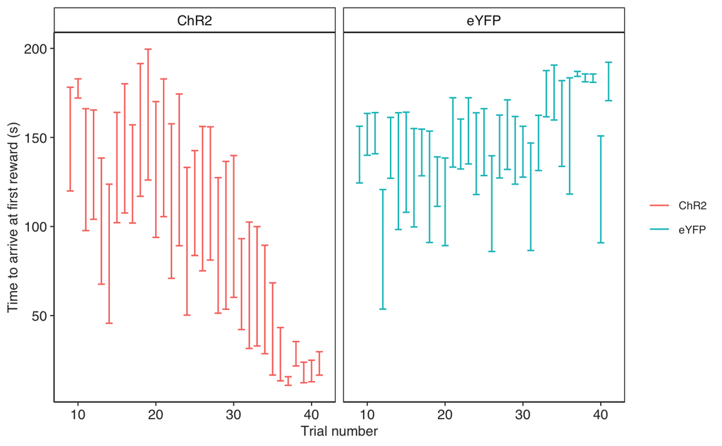

Changes for each individual animal

[interactive chart not shown]

Day average

[interactive chart not shown]

Stella edit - show data for each animal

[output not shown]

[interactive chart not shown]

Stella edit - show mean data from trial

[interactive chart not shown]

# Time dwelling inside reward zone

[interactive chart not shown]

# Time inside reward zone during test trial

[interactive chart not shown]

# Comparison with habituation trials

Calculate number of crossings during habituation for each location set

[output not shown]

Average across habituation trials on the day